# HW_14

Cody Grainger

07 August 2020

### Libraries

Initial libraries

```r
library(here)
library(raster)
library(sf)
library(tidyverse)
library(ggthemes)
library(patchwork)
library(maptools)
library(ggmap)
library(marmap)
```

#### Part 1: Outline maps

### Notes

packages ‘map_data’ and ‘subset’ are used to access specific regions (states)

```r
# Outline of the 48 contiguous states
usa <- map_data(map="state")

# Outline of just Missouri
us_missouri <- map_data(map="state",
                        region="missouri")

# Outline of Alabama, Florida, Mississippe, and North Carolina
us_other <- subset(x=usa,
                   subset=region %in% c("alabama",
                                        "florida",
                                        "mississippi",
                                        "north carolina"))
```

observing the structure of the usa data frame

```r
str(usa)
```

```
'data.frame':   15537 obs. of  6 variables:
 $ long     : num  -87.5 -87.5 -87.5 -87.5 -87.6 ...
 $ lat      : num  30.4 30.4 30.4 30.3 30.3 ...
 $ group    : num  1 1 1 1 1 1 1 1 1 1 ...
 $ order    : int  1 2 3 4 5 6 7 8 9 10 ...
 $ region   : chr  "alabama" "alabama" "alabama" "alabama" ...
 $ subregion: chr  NA NA NA NA ...
```

```r
head(usa)
```

|  | long | lat | group | order | region | subregion |
| --- | --- | --- | --- | --- | --- | --- |
| 1 | -87.46201 | 30.38968 | 1 | 1 | alabama | NA |
| 2 | -87.48493 | 30.37249 | 1 | 2 | alabama | NA |
| 3 | -87.52503 | 30.37249 | 1 | 3 | alabama | NA |
| 4 | -87.53076 | 30.33239 | 1 | 4 | alabama | NA |
| 5 | -87.57087 | 30.32665 | 1 | 5 | alabama | NA |
| 6 | -87.58806 | 30.32665 | 1 | 6 | alabama | NA |

Plotting the ‘us_other’ states. the fill is set to “gray”

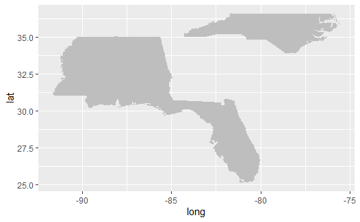

```r
ggplot()+
  geom_polygon(data=us_other,
               aes(x=long,y=lat,
                   group=group),
               fill="gray")
```

The code below will add missouri with the fill set to “black” to the original plot.

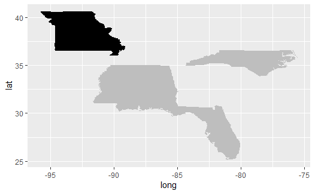

```r
ggplot()+
  geom_polygon(data=us_other,
               aes(x=long,y=lat,
                   group=group),
               fill="gray") +
  geom_polygon(data=us_missouri,
               aes(x=long,y=lat,
                   group=group),
               fill="black")
```

The outline of the US mainland is added

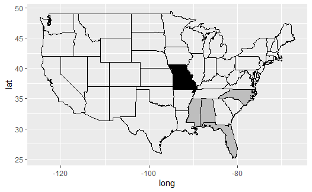

```r
ggplot()+
  geom_polygon(data=us_other,
               aes(x=long,y=lat,
                   group=group),
               fill="gray") +
  geom_polygon(data=us_missouri,
               aes(x=long,y=lat,
                   group=group),
               fill="black") +
  geom_polygon(data=usa,
               aes(x=long,y=lat,
                   group=group),
               fill=NA,
               color="black")
```

# US map

Now adding the map theme from ‘ggthemes’ and a coord_fixed layer set to 1.3

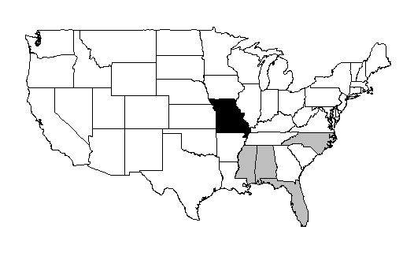

```r
us_map <- ggplot()+
  geom_polygon(data=us_other,
               aes(x=long,y=lat,
                   group=group),
               fill="gray") +
  geom_polygon(data=us_missouri,
               aes(x=long,y=lat,
                   group=group),
               fill="black") +
  geom_polygon(data=usa,
               aes(x=long,y=lat,
                   group=group),
               fill=NA,
               color="black") +
  theme_map() +
  coord_fixed(1.3)

us_map
```

# Missouri map

A map of missouri divided by counties with scott county filled in black

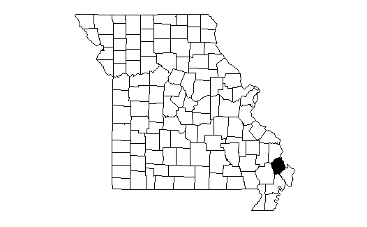

```r
missouri <- map_data("county","missouri")
mo_scott <- subset(missouri, subregion %in% c("scott"))

mo_map <- ggplot() +
  geom_polygon(data=missouri,aes(x=long,y=lat,group=group),fill=NA,color="black") +
  geom_polygon(data=mo_scott,aes(x=long,y=lat,group=group),fill="black") +
  theme_map() +
  coord_fixed(1.3)

mo_map
```

using the patchwork package to set the us map and missouri map side by side. width of the us map is set to 1.5 times wider

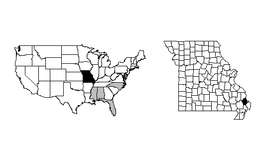

```r
us_map + mo_map + plot_layout(ncol=2,widths=c(1.5,1))
```

##Outline maps: your turn

California is filled in black on the us_map. San Diego county will be filled in black and Glenn and Contra Costa counties will be shaded gray. the maps are put side by side with patchwork. patchwork width set to 1.8

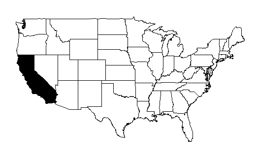

```r
# Outline of the 48 contiguous states
usa <- map_data(map="state")

# Outline of just California
us_california <- map_data(map="state",
                        region="california")


us_map <- ggplot()+
  geom_polygon(data=us_california,
               aes(x=long,y=lat,
                   group=group),
               fill="black") +
  geom_polygon(data=usa,
               aes(x=long,y=lat,
                   group=group),
               fill=NA,
               color="black") +
  theme_map() +
  coord_fixed(1.3)

us_map
```

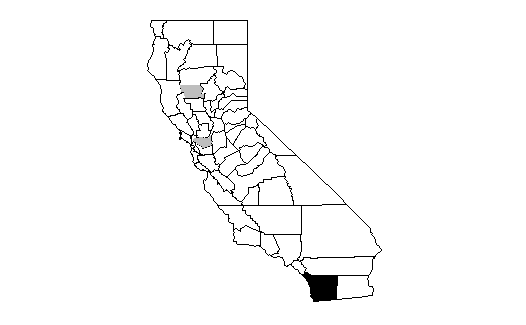

```r
california <- map_data("county","california")
ca_san_diego <- subset(california, subregion %in% c("san diego"))
ca_other <- subset(california, subregion %in% c("glenn","contra costa"))

ca_map <- ggplot() +
  geom_polygon(data=california,aes(x=long,y=lat,group=group),fill=NA,color="black") +
  geom_polygon(data=ca_san_diego,aes(x=long,y=lat,group=group),fill="black") +
  geom_polygon(data=ca_other,aes(x=long,y=lat,group=group),fill="grey") +
  theme_map() +
  coord_fixed(1.3)

ca_map
```

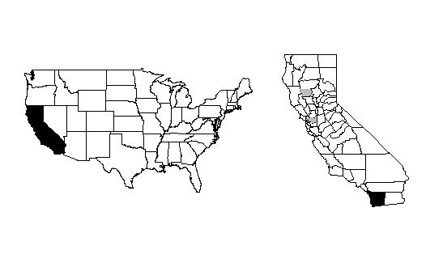

```r
us_map + ca_map + plot_layout(ncol=2,widths=c(1.8,1))
```

#### Part 2: Choropleth maps

# Example

skin cancer mortality in the US

importing data using read_delim()

```r
skin_cancer_raw <- read_delim(file=here::here("data","skin_cancer.txt"),
             delim=" ",
             skip=7,
             trim_ws=TRUE)
skin_cancer_raw
```

| State | Lat | Mort | Ocean | Long |
| --- | --- | --- | --- | --- |
| Alabama | 33.0 | 219 | 1 | 87.0 |
| Arizona | 34.5 | 160 | 0 | 112.0 |
| Arkansas | 35.0 | 170 | 0 | 92.5 |
| California | 37.5 | 182 | 1 | 119.5 |
| Colorado | 39.0 | 149 | 0 | 105.5 |
| Connecticut | 41.8 | 159 | 1 | 72.8 |
| Delaware | 39.0 | 200 | 1 | 75.5 |
| Wash,D.C. | 39.0 | 177 | 0 | 77.0 |
| Florida | 28.0 | 197 | 1 | 82.0 |
| Georgia | 33.0 | 214 | 1 | 83.5 |

[output cut: 39 more lines]

Wrangling the data to put spaces in state names and correct a typo

```r
#removing spaces and correcting MewYork to New York
skin_cancer <- skin_cancer_raw %>%
  filter(State!="Wash,D.C.") %>%
  mutate(State=case_when(
    State=="NorthCarolina" ~ "North Carolina",
    State=="SouthCarolina" ~ "South Carolina",
    State=="NorthDakota" ~ "North Dakota",
    State=="SouthDakota" ~ "South Dakota",
    State=="NewHampshire" ~ "New Hampshire",
    State=="NewJersey" ~ "New Jersey",
    State=="NewMexico" ~ "New Mexico",
    State=="MewYork" ~ "New York",
    State=="RhodeIsland" ~ "Rhode Island",
    State=="WestVirginia" ~ "West Virginia",
    TRUE ~ State))
```

```r
# Finding the mean_mort value
mean_mort <- mean(skin_cancer$Mort)

# using the new value to create a new columns with mutate
skin_cancer_adj <- skin_cancer %>%
  mutate(relative_mort=Mort - mean_mort)
```

Removing Hawaii, Alaska, the District of Columbia, and US territories from our shapefile.

```r
lower_48 <- c("Alabama","Arizona","Arkansas","California","Colorado","Connecticut","Delaware","Florida","Georgia","Idaho","Illinois","Indiana","Iowa","Kansas","Kentucky","Louisiana","Maine","Maryland","Massachusetts","Michigan","Minnesota","Mississippi","Missouri","Montana","Nebraska","Nevada","New Hampshire","New Jersey","New Mexico","New York","North Carolina","North Dakota","Ohio","Oklahoma","Oregon","Pennsylvania","Rhode Island","South Carolina","South Dakota","Tennessee","Texas","Utah","Vermont","Virginia","Washington","West Virginia","Wisconsin","Wyoming")
```

reading the shapefile with st_read. Filter is used so we only get the 48 states.

```r
states <- st_read(here::here("data", "cb_2017_us_state_500k.shp"),
                  stringsAsFactors=TRUE)
#lower 48
states_df <- states %>%
  dplyr::filter(NAME %in% lower_48)
```

Assigning levels to the states with state FIPS data

```r
# Capture the FIPS levels from states_df
# Use to factor the FIPS and state names in the next step.
state_levels <- levels(states_df$STATEFP)
name_levels <- levels(states_df$NAME)
```

Using mutate() to change ‘STATEFP’ to an unordered factor

```r
library(tidyverse)
fips <- read_csv(here::here("data","state_fips.csv")) %>%
  dplyr::select(-abbr) %>%
  rename(STATEFP=FIPS) %>%
  mutate(STATEFP=factor(STATEFP,levels=state_levels))
```

Using left join() to merge data into a single file

```r
skin_cancer_adj <- left_join(skin_cancer_adj, fips)
states_df <- left_join(states_df, skin_cancer_adj)
```

plotting with grom_sf. coord_sf() will warp the plot to mimic the Earth curvature for theme_bw(). theme(legend.position=“bottom”)

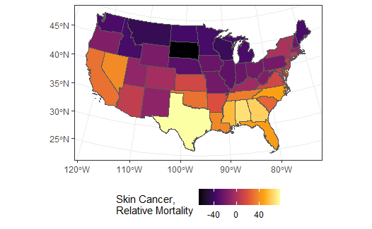

```r
ggplot(states_df) +
  geom_sf(aes(fill=relative_mort)) +
  scale_fill_viridis_c(name="Skin Cancer,\nRelative Mortality",
                       option="inferno") +
  coord_sf(crs=st_crs(5070)) +
  theme_bw() +
  theme(legend.position="bottom")
```